# Xyplot Ordering

### Problem

While working on HW 3 I was somewhat confused by the order of the slopes and intercepts by xyplot. For personal interest I wanted to recreate the plot with ggplot2. I thought that xyplot orders the panels based on the intercept and slopes of a multilevel model. However, it became clear that this is not the case. So, to save you confusion and time in the future on that I decided put it on BB. To see what I mean I show it with the example that is familiar to all of us now using the task from the HW3:

```r
#center variable
df$c_trial <- df$num_trial - mean(df$num_trial)
#fit model
fit <- lmer(distance ~ gender * c_trial + (1 + c_trial|pid) , data=df)
```

So, here the xyplot with descending order of intercepts (if you read from left to right, bottom to top). I used c_trial because I used c_trial also for the model. You can also use num_trial but then you also have to use num_trial in the model since the goal here is to compare intercepts. Beware that the intercept is now in the middle of the plot and not left due to centering.

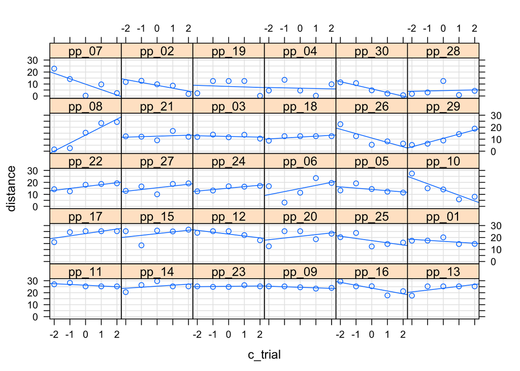

```r
xyplot(distance ~ c_trial | pid, data=df, type=c('g', 'p', 'r'), index.cond =  function(x,y) -coef(lm(y ~ x))[1])
```

In the following, I fit a linear regression for each individual using also c_trial. I further extract the MLM coefficients including the deviations from the fixed parameters, store everything in a dataframe and then we can order that dataframe by the parameter of interest to check which order is similar to the order xyplot uses:

```r
#Store coefs in dataframe
cf <- coef(fit)$pid %>% rownames_to_column('pid')
#change colnames of dataframe
names(cf) <- c('pid', 'mlm_intercepts', 'gender_coef', 'mlm_slopes', 'interaction')
#Same for deviations from fixed effects:
cf2 <- ranef(fit)$pid %>% rownames_to_column('pid')
names(cf2) <- c('pid', 'mlm_intercepts_dev', 'mlm_slopes_dev')
#Perform linear regression for each individual:
fitted_models = df %>% group_by(pid) %>% do(model = lm(distance ~ c_trial, data = .))
#Create df for each estimate
df3 <- fitted_models %>% tidy(model) %>% dlply("term", identity)
lm_coefs <- data.frame(pid=df3$`(Intercept)`$pid, lm_intercepts=df3$`(Intercept)`$estimate, lm_slopes=df3$c_trial$estimate)
#Store in one df and sort by mlm_intercept:
descending_mlm_intercepts <- dplyr::select(cf, pid, mlm_intercepts, mlm_slopes) %>%
  left_join(cf2, by='pid') %>%
  left_join(lm_coefs, by='pid') %>%
  dplyr::select(pid, mlm_intercepts, mlm_intercepts_dev, lm_intercepts, mlm_slopes, mlm_slopes_dev, lm_slopes) %>%
  arrange(desc(mlm_intercepts))
#Store in one df and sort by lm_intercept:
descending_lm_intercepts <- dplyr::select(cf, pid, mlm_intercepts, mlm_slopes) %>%
  left_join(cf2, by='pid') %>%
  left_join(lm_coefs, by='pid') %>%
  dplyr::select(pid, mlm_intercepts, mlm_intercepts_dev, lm_intercepts, mlm_slopes, mlm_slopes_dev, lm_slopes) %>%
  arrange(desc(lm_intercepts))
```

### Compare with df

You can see in this df the order of pid how it should be if you want order by the intercepts and slopes provided by lme object. I put the xyplot again here so you can directly compare and see that the order does not match:

```r
descending_mlm_intercepts
```

| pid | mlm_intercepts | mlm_intercepts_dev | lm_intercepts | mlm_slopes | mlm_slopes_dev | lm_slopes |
| --- | --- | --- | --- | --- | --- | --- |
| pp_09 | 26.8670 | 10.886209 | 24.5056 | 0.19842 | 0.27703 | -0.44509 |
| pp_16 | 26.3315 | 10.350645 | 23.8287 | -1.09083 | -1.01222 | -2.39532 |
| pp_11 | 22.0019 | 6.021044 | 26.2332 | -1.32427 | -1.24566 | -0.63890 |
| pp_14 | 21.2216 | 5.240771 | 25.4267 | -0.31497 | -0.23635 | 0.85055 |
| pp_23 | 21.1494 | 5.168546 | 25.3169 | -0.78616 | -0.70755 | 0.14162 |
| pp_13 | 19.6845 | 3.703651 | 23.7452 | 0.18466 | 0.26328 | 1.55207 |
| pp_22 | 19.6355 | 3.654714 | 16.5426 | 1.71114 | 1.78975 | 1.59868 |
| pp_17 | 19.2777 | 3.296863 | 23.3073 | 0.43136 | 0.50997 | 1.90940 |
| pp_15 | 19.2529 | 3.272102 | 23.2594 | 0.10593 | 0.18454 | 1.42055 |
| pp_12 | 19.0053 | 3.024512 | 22.8595 | -1.88820 | -1.80959 | -1.57787 |

[output cut: 20 more lines]

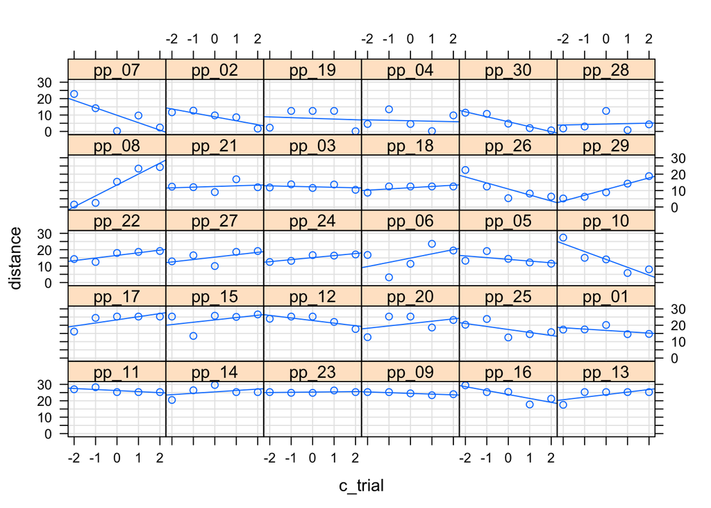

```r
xyplot(distance ~ c_trial | pid, data=df, type=c('g', 'p', 'r'), index.cond =  function(x,y) -coef(lm(y ~ x))[1])
```

I can reproduce the order with intercepts that I obtained by running an isolated linear regression (that one you can only run without gender since each pid has only one gender).

```r
descending_lm_intercepts
```

| pid | mlm_intercepts | mlm_intercepts_dev | lm_intercepts | mlm_slopes | mlm_slopes_dev | lm_slopes |
| --- | --- | --- | --- | --- | --- | --- |
| pp_11 | 22.0019 | 6.021044 | 26.2332 | -1.32427 | -1.24566 | -0.63890 |
| pp_14 | 21.2216 | 5.240771 | 25.4267 | -0.31497 | -0.23635 | 0.85055 |
| pp_23 | 21.1494 | 5.168546 | 25.3169 | -0.78616 | -0.70755 | 0.14162 |
| pp_09 | 26.8670 | 10.886209 | 24.5056 | 0.19842 | 0.27703 | -0.44509 |
| pp_16 | 26.3315 | 10.350645 | 23.8287 | -1.09083 | -1.01222 | -2.39532 |
| pp_13 | 19.6845 | 3.703651 | 23.7452 | 0.18466 | 0.26328 | 1.55207 |
| pp_17 | 19.2777 | 3.296863 | 23.3073 | 0.43136 | 0.50997 | 1.90940 |
| pp_15 | 19.2529 | 3.272102 | 23.2594 | 0.10593 | 0.18454 | 1.42055 |
| pp_12 | 19.0053 | 3.024512 | 22.8595 | -1.88820 | -1.80959 | -1.57787 |
| pp_20 | 17.2463 | 1.265493 | 21.0266 | 0.15235 | 0.23096 | 1.42775 |

[output cut: 20 more lines]

### In case you want to order by intercept of the MLM

This plot orders by the mlm intercept. You need to read from left to right, top to bottom. You can do the same for slopes or any other parameter if you want. Again, I use c_trial so beware that the intercept is in the middel of the plot now.

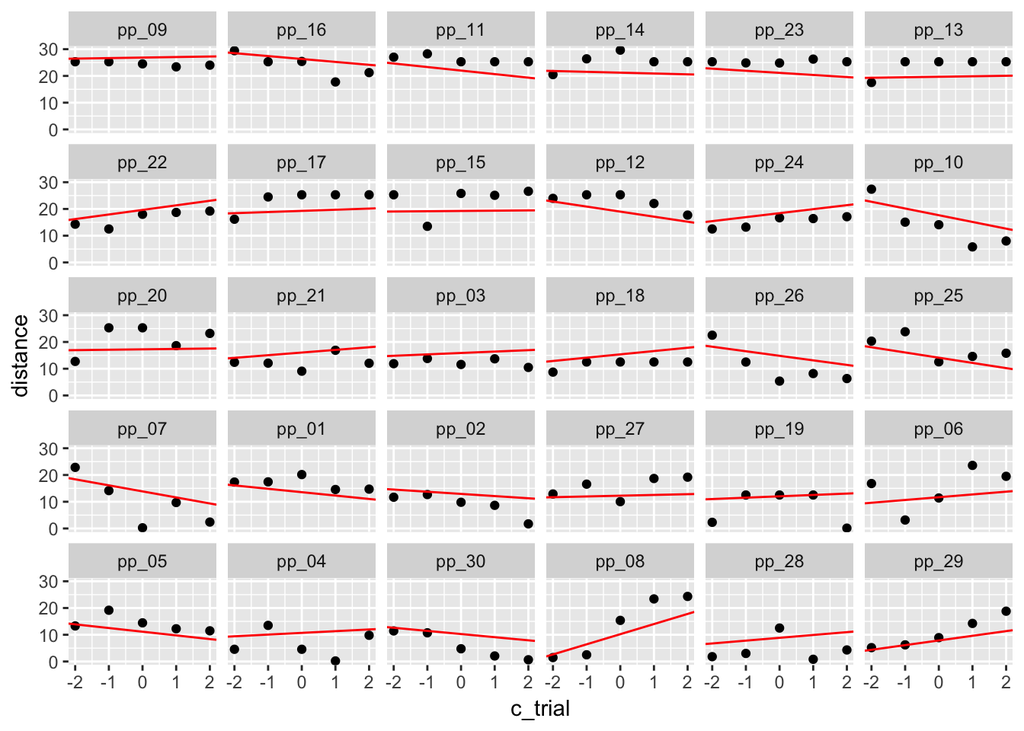

```r
df <- left_join(df, cf, by='pid') %>% mutate(pid=reorder(pid, -mlm_intercepts))
##plot ordered by intercept
ggplot(df, aes(c_trial, distance)) +
  geom_point() +
  geom_abline(aes(intercept=mlm_intercepts, slope=mlm_slopes),color='red') +
  facet_wrap(~pid)
```

```r
descending_mlm_intercepts
```

| pid | mlm_intercepts | mlm_intercepts_dev | lm_intercepts | mlm_slopes | mlm_slopes_dev | lm_slopes |
| --- | --- | --- | --- | --- | --- | --- |
| pp_09 | 26.8670 | 10.886209 | 24.5056 | 0.19842 | 0.27703 | -0.44509 |
| pp_16 | 26.3315 | 10.350645 | 23.8287 | -1.09083 | -1.01222 | -2.39532 |
| pp_11 | 22.0019 | 6.021044 | 26.2332 | -1.32427 | -1.24566 | -0.63890 |
| pp_14 | 21.2216 | 5.240771 | 25.4267 | -0.31497 | -0.23635 | 0.85055 |
| pp_23 | 21.1494 | 5.168546 | 25.3169 | -0.78616 | -0.70755 | 0.14162 |
| pp_13 | 19.6845 | 3.703651 | 23.7452 | 0.18466 | 0.26328 | 1.55207 |
| pp_22 | 19.6355 | 3.654714 | 16.5426 | 1.71114 | 1.78975 | 1.59868 |
| pp_17 | 19.2777 | 3.296863 | 23.3073 | 0.43136 | 0.50997 | 1.90940 |
| pp_15 | 19.2529 | 3.272102 | 23.2594 | 0.10593 | 0.18454 | 1.42055 |
| pp_12 | 19.0053 | 3.024512 | 22.8595 | -1.88820 | -1.80959 | -1.57787 |

[output cut: 20 more lines]

Please let me know if you find any mistakes or if I overlooked something.